# TF1_資料彙整與切割

第十一組

2019-06-18 20:35:53

### part 1 交易項目計錄：

```r
rm(list=ls(all=T))
Sys.setlocale("LC_TIME","C")
```

```
## [1] "C"
```

```r
pacman::p_load(magrittr, readr, caTools, ggplot2, dplyr)
```

##### 1.1 資料匯入

```r
A = read_csv("data/ta_feng_all_months_merged.csv") %>%
  data.frame %>%
  setNames(c("date","cid","age","area","category","pid","quan","cost","price"))
nrow(A)
```

```
## [1] 817741
```

##### 資料格式整理

```r
A$date = as.Date(A$date, format ="%m/%d/%Y")
A$age[is.na(A$age)] = "na"
A$age = factor(A$age, levels=c(
  "<25","25-29","30-34","35-39","40-44","45-49","50-54","55-59","60-64",">65","na"), labels=c(
  "a20","a25","a30","a35","a40","a45","a50","a55","a60","a65","na"
  )) %>% as.character
A$area = paste0("A",A$area)
summary(A)
```

```
##       date                cid                age
##  Min.   :2000-11-01   Length:817741      Length:817741
##  1st Qu.:2000-11-28   Class :character   Class :character
##  Median :2001-01-01   Mode  :character   Mode  :character
##  Mean   :2000-12-30
##  3rd Qu.:2001-01-30
##  Max.   :2001-02-28
##      area              category          pid                 quan
##  Length:817741      Min.   :100101   Length:817741      Min.   :   1.000
##  Class :character   1st Qu.:110106   Class :character   1st Qu.:   1.000
##  Mode  :character   Median :130106   Mode  :character   Median :   1.000
##                     Mean   :284951                      Mean   :   1.382
##                     3rd Qu.:520314                      3rd Qu.:   1.000
##                     Max.   :780510                      Max.   :1200.000
##       cost              price
##  Min.   :     0.0   Min.   :     1.0
##  1st Qu.:    35.0   1st Qu.:    42.0
##  Median :    62.0   Median :    76.0
##  Mean   :   112.1   Mean   :   131.9
##  3rd Qu.:   112.0   3rd Qu.:   132.0
##  Max.   :432000.0   Max.   :444000.0
```

##### 處理outlier

```r
sapply(A[,7:9], quantile, prob=c(.99, .999, .9995)) #把數量、成本及售價離群處理掉
```

```
##        quan   cost   price
## 99%       6  858.0 1014.00
## 99.9%    14 2722.0 3135.82
## 99.95%   24 3799.3 3999.00
```

```r
A = subset(A, quan<=24 & cost<=3800 & price<=4000)

nrow(A) #減少559
```

```
## [1] 817182
```

##### 彙總訂單 Assign Transaction ID

```r
A$tid = group_indices(A, date, cid) # same customer same day
```

##### 資料簡易分析

```r
sapply(A[c("cid","category","pid","tid")], n_distinct)
```

```
##      cid category      pid      tid
##    32256     2007    23789   119422
```

### part 2 交易紀錄 : 以每筆交易訂單tid為主軸

```r
B = A %>% group_by(tid) %>%
  summarise(
  date = date[1],             # 交易日期
  cid = cid[1],               # 顧客 ID
  age = age[1],               # 顧客 年齡級別
  area = area[1],             # 顧客 居住區別
  items = n(),                # 交易項目(總)數
  pieces = sum(quan),         # 產品(總)件數
  total = sum(price),         # 交易(總)金額
  profit = sum(price - cost)  # 毛利
  ) %>% data.frame
summary(B)
```

```
##       tid              date                cid
##  Min.   :     1   Min.   :2000-11-01   Length:119422
##  1st Qu.: 29856   1st Qu.:2000-11-29   Class :character
##  Median : 59712   Median :2001-01-01   Mode  :character
##  Mean   : 59712   Mean   :2000-12-31
##  3rd Qu.: 89567   3rd Qu.:2001-02-02
##  Max.   :119422   Max.   :2001-02-28
##      age                area               items             pieces
##  Length:119422      Length:119422      Min.   :  1.000   Min.   :  1.000
##  Class :character   Class :character   1st Qu.:  2.000   1st Qu.:  3.000
##  Mode  :character   Mode  :character   Median :  5.000   Median :  6.000
##                                        Mean   :  6.843   Mean   :  9.294
##                                        3rd Qu.:  9.000   3rd Qu.: 12.000
##                                        Max.   :112.000   Max.   :339.000
##      total           profit
##  Min.   :    5   Min.   :-1645.0
##  1st Qu.:  227   1st Qu.:   21.0
##  Median :  510   Median :   68.0
##  Mean   :  859   Mean   :  132.3
##  3rd Qu.: 1082   3rd Qu.:  169.0
##  Max.   :30171   Max.   : 8069.0
```

##### 處理outlier

```r
sapply(B[,6:9], quantile, prob=c(.99, .9995, .9999)) #把數量、成本及售價離群處理掉
```

```
##        items   pieces    total   profit
## 99%       33  46.0000  4972.58  960.000
## 99.95%    62  94.2895 10611.58 2179.817
## 99.99%    82 133.0000 16044.40 3226.548
```

```r
B = subset(B, items<=62 & pieces<95 & total<16000)

nrow(B) #119422-119328=94 減少94
```

```
## [1] 119328
```

#### 每週交易次數

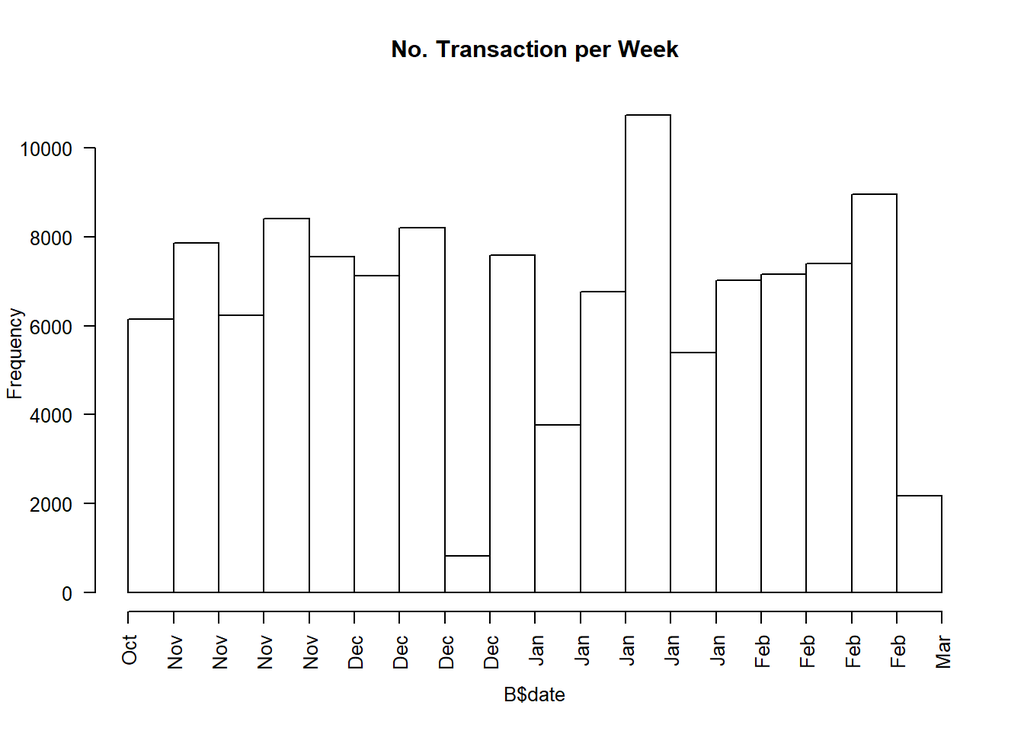

```r
par(cex=0.8)
hist(B$date,"weeks" ,freq=T, las=2, main="No. Transaction per Week")
```

### part 3 建立顧客資料 “C”

```r
d0 = max(B$date) + 1
C = B %>% mutate(
  days = as.integer(difftime(d0, date, units="days"))
  ) %>%
  group_by(cid) %>% summarise(
    r = min(days),      # recency
    s = max(days),      # seniority
    f = n(),            # frquency
    m = mean(total),    # monetary
    rev = sum(total),   # total revenue contribution
    raw = sum(profit),  # total gross profit contribution
    age = age[1],       # age group
    area = area[1]      # area code
  ) %>% data.frame      # 33241
nrow(C)
```

```
## [1] 32241
```

##### 顧客摘要

```r
summary(C)
```

```
##      cid                  r                s                f
##  Length:32241       Min.   :  1.00   Min.   :  1.00   Min.   : 1.000
##  Class :character   1st Qu.:  9.00   1st Qu.: 56.00   1st Qu.: 1.000
##  Mode  :character   Median : 26.00   Median : 92.00   Median : 2.000
##                     Mean   : 37.45   Mean   : 80.78   Mean   : 3.701
##                     3rd Qu.: 60.00   3rd Qu.:110.00   3rd Qu.: 4.000
##                     Max.   :120.00   Max.   :120.00   Max.   :85.000
##        m                rev              raw              age
##  Min.   :    8.0   Min.   :     8   Min.   : -784.0   Length:32241
##  1st Qu.:  365.0   1st Qu.:   707   1st Qu.:   75.0   Class :character
##  Median :  705.7   Median :  1750   Median :  241.0   Mode  :character
##  Mean   :  993.1   Mean   :  3152   Mean   :  484.6
##  3rd Qu.: 1291.0   3rd Qu.:  3968   3rd Qu.:  612.0
##  Max.   :12636.0   Max.   :127686   Max.   :20273.0
##      area
##  Length:32241
##  Class :character
##  Mode  :character
##
##
##
```

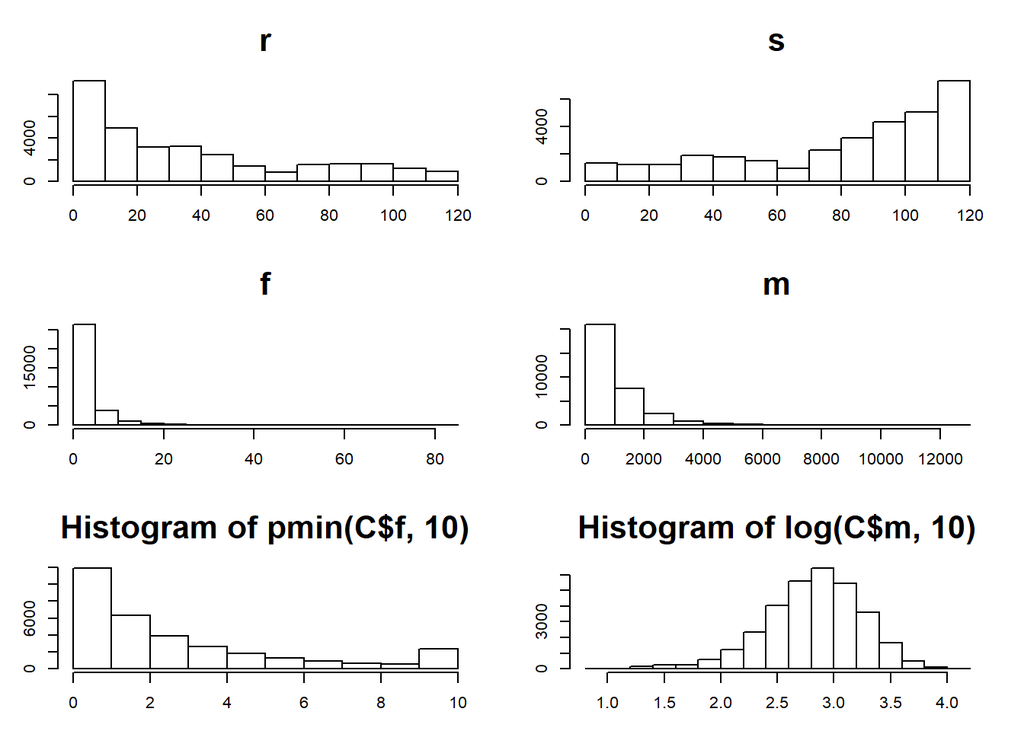

```r
par(mfrow=c(3,2), mar=c(3,3,4,2))
for(x in c('r','s','f','m'))
  hist(C[,x],freq=T,main=x,xlab="",ylab="",cex.main=2)
hist(pmin(C$f,10),0:10,freq=T,xlab="",ylab="",cex.main=2)
hist(log(C$m,10),freq=T,xlab="",ylab="",cex.main=2)
```

##### 儲存各個資料集

```r
is.na(A) %>% colSums
```

```
##     date      cid      age     area category      pid     quan     cost
##        0        0        0        0        0        0        0        0
##    price      tid
##        0        0
```

```r
is.na(B) %>% colSums
```

```
##    tid   date    cid    age   area  items pieces  total profit
##      0      0      0      0      0      0      0      0      0
```

```r
is.na(C) %>% colSums
```

```
##  cid    r    s    f    m  rev  raw  age area
##    0    0    0    0    0    0    0    0    0
```

```r
A0 = A; B0 = B; C0 = C
save(A0,B0,C0, file="data/tf0.rdata")
```

### part 4 切割資料準備

```r
rm(list=ls(all=TRUE))
Sys.setlocale("LC_TIME","C")
```

```
## [1] "C"
```

```r
pacman::p_load(magrittr, readr, caTools, ggplot2, dplyr)
load("data/tf0.rdata")
```

##### 以二月為分割時間，切割出二月前的資料

```r
feb01 = as.Date("2001-02-01")
Z = subset(A0, date < feb01)
```

```r
X = group_by(Z, tid) %>% summarise(
  date = first(date),  # 交易日期
  cid = first(cid),  # 顧客 ID
  age = first(age),    # 顧客 年齡級別
  area = first(area),  # 顧客 居住區別
  items = n(),        # 交易項目(總)數
  pieces = sum(quan),          # 產品(總)件數
  total = sum(price),         # 交易(總)金額
  gross = sum(price - cost)   # 毛利
  ) %>% data.frame
summary(X)
```

```
##       tid             date                cid
##  Min.   :    1   Min.   :2000-11-01   Length:88387
##  1st Qu.:22098   1st Qu.:2000-11-23   Class :character
##  Median :44194   Median :2000-12-12   Mode  :character
##  Mean   :44194   Mean   :2000-12-15
##  3rd Qu.:66291   3rd Qu.:2001-01-12
##  Max.   :88387   Max.   :2001-01-31
##      age                area               items             pieces
##  Length:88387       Length:88387       Min.   :  1.000   Min.   :  1.000
##  Class :character   Class :character   1st Qu.:  2.000   1st Qu.:  3.000
##  Mode  :character   Mode  :character   Median :  5.000   Median :  6.000
##                                        Mean   :  6.994   Mean   :  9.453
##                                        3rd Qu.:  9.000   3rd Qu.: 12.000
##                                        Max.   :112.000   Max.   :339.000
##      total             gross
##  Min.   :    5.0   Min.   :-1645.0
##  1st Qu.:  230.0   1st Qu.:   23.0
##  Median :  522.0   Median :   72.0
##  Mean   :  888.7   Mean   :  138.3
##  3rd Qu.: 1120.0   3rd Qu.:  174.0
##  Max.   :30171.0   Max.   : 8069.0
```

##### 去除outlier

```r
sapply(X[,6:9], quantile, prob=c(.999, .9995, .9999))
```

```
##          items   pieces     total    gross
## 99.9%  56.0000  84.0000  9378.684 1883.228
## 99.95% 64.0000  98.0000 11261.751 2317.087
## 99.99% 85.6456 137.6456 17699.325 3389.646
```

```r
X = subset(X, items<=64 & pieces<=98 & total <= 11260) # 88387 -> 88295
```

```r
d0 = max(X$date) + 1
A = X %>% mutate(
  days = as.integer(difftime(d0, date, units="days"))
  ) %>%
  group_by(cid) %>% summarise(
    r = min(days),      # recency
    s = max(days),      # seniority
    f = n(),            # frquency
    m = mean(total),    # monetary
    rev = sum(total),   # total revenue contribution
    raw = sum(gross),   # total gross profit contribution
    age = age[1],   # age group
    area = area[1]    # area code
  ) %>% data.frame
nrow(A)
```

```
## [1] 28584
```

### part 5 衍生變數

##### 所有變數列表

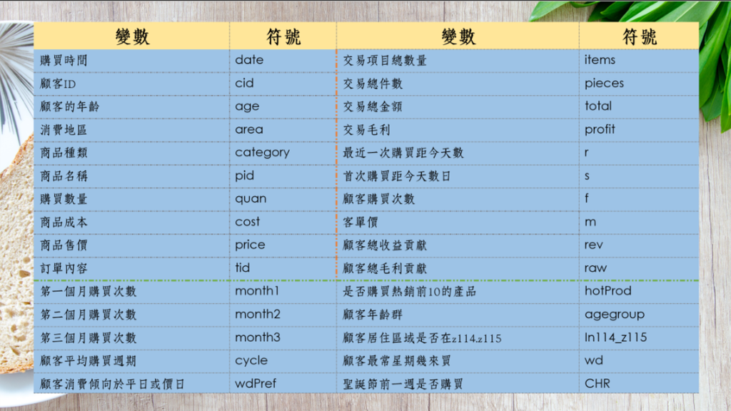

Fig-1: All Variables

##### 前10個熱銷產品分別購買次數

- hotprod 以是否有購買產品熱銷前10的產品做為區隔， 看出購買這些產品的人是否為特定族群或者有其他的特性
- 用`xtabs()`做顧客產品矩陣
- row: customer
- col: product

```r
library(Matrix)
library(slam)

Z = subset(Z, cid %in% A$cid)
cpm = xtabs(~ cid + pid, Z, sparse=T)
```

刪除購買次數小於10的產品

```r
table(colSums(cpm) < 10)       # 9652
```

```
##
## FALSE  TRUE
##  9652 12862
```

```r
cpm = cpm[, colSums(cpm) > 10]
cpm = cpm[, order(-colSums(cpm))]   # order product by frequency
dim(cpm)                       # 28584  9159
```

```
## [1] 28584  9149
```

確認cpm和A的顧客順序及大小是否有相同

```r
cpm = cpm %>% as.matrix
(A$cid == rownames(cpm)) %>% sum
```

```
## [1] 28584
```

合併兩個資料並將欄位名稱變更

```r
A = cbind(A,cpm[,1:10])

colnames(A)[10:19] = sapply(seq(1,10,1), function(x){
  names = paste0("p",x)
})
```

##### 顧客年齡群

```r
A$ageGroup<- as.factor(A$age)
A$ageGroup<-factor(A$ageGroup, levels=c("a20", "a25", "a30", "a35","a40", "a45", "a50", "a55", "a60", "a65", "na"), labels=c("A1", "A1", "A1", "A1", "A2", "A2", "A2", "A3", "A3", "A3", "na"))
```

##### 聖誕節購買幾次

找出聖誕節前一週的區間

```r
CHR1 = as.Date("2000-12-17")
CHR2= as.Date("2000-12-23")
# as.Date("2000-12-25") %>% format("%U")
```

- 依照顧客做分群設立新變數聖誕節前一週購買次數(CHR)
- 將所有交易時間與該區間進行比較，若有購買則為1,若非則為0

```r
NewVar = group_by(X, cid) %>%
  summarise(
    CHR = sum( ifelse(date > CHR1 & date < CHR2, 1, 0 ) )
  )
```

合併資料

```r
A = left_join(A, NewVar)
```

##### 消費者消費傾向於平日或假日

- 用`xtab()`做出一個矩陣，每個值代表該顧客在每個星期購買幾次
- row: customer
- col: weekday
- 把每個值除以該列總和，則變為機率: (該顧客在每個星期購買的機率)
- 變成data.frame，並新增wk15 & wk67欄位
- wk15: 平日購買的機率
- wk67: 假日購買的機率

```r
X = X %>% mutate(wday = format(date, "%w"))

mx = xtabs(~ cid + wday, X)
dim(mx)
```

```
## [1] 28584     7
```

```r
mx = mx / rowSums(mx)  # count -> probability

W = data.frame(as.character(rownames(mx)), as.matrix.data.frame(mx)) %>%
  setNames(c("cust","W7","W1","W2","W3","W4","W5","W6")) %>%
  mutate(
    wk15 = W1+W2+W3+W4+W5,
    wk67 = W6+W7
  )
```

- 判斷顧客可能比較會在平日or假日購買
- na代表沒有特別偏好

```r
W$wdPref = ifelse((W$wk15 < W$wk67), "Weekend",
         ifelse(W$wk15 == W$wk67, "Na", "Weekday"))
W$wdPref = as.factor(W$wdPref)
```

合併資料

```r
A = merge(A, W[,c("cust","wdPref")], by.x="cid", by.y="cust")
```

##### 顧客最常星期幾來買(wd)

- 自定義一個計算的function `maxWeekday`，待會在summarise時可以使用
- na: 表示沒有特別偏好星期幾
- 步驟:
- 先把每筆交易日期取簡寫的星期(%a)
- 用table()計算出每個星期的交易次數
- 用ifelse()判斷，如果沒有哪個星期交易量特別大則為“na”，如果有則取出最常交易的星期

```r
maxWeekday = function(x){
  y = format(x,"%a") %>% table
  d = ifelse(sum(y==max(y))>1, "na", names(which.max(y)))
  return(d)
}
```

##### 其他衍生變數

- month1/month2/month3

我們以月分做為區隔，把顧客在這三個月裡的購買次數個別加總，藉由觀察各個月的購買次數來看出顧客消費趨勢的變化

```r
NewVar = group_by(X, cid) %>%
  summarise(
    weekday = maxWeekday(date),                                                   # 顧客最常禮拜幾來買
    avgPrice = mean(total / pieces),                                              # 商品平均單價
    mon1 = sum(date < as.Date("2000-12-01")),                                     # 第一個月購買的次數
    mon2 = sum((date < as.Date("2001-01-01") & (date >= as.Date("2000-12-01")))), # 第二個月購買的次數
    mon3 = sum(date >= as.Date("2001-01-01")),                                    # 第三個月購買的次數
    in114_115 = ifelse(area[1] %in% c("A114", "A115"), T, F)                    # 居住區域是否在A114.A115
  ) %>% data.frame    # 28584
```

幫weekday排順序

```r
NewVar$weekday = factor(NewVar$weekday, levels= c("Mon", "Tue", "Wed", "Thu", "Fri", "Sat", "Sun", "na"))
```

```r
A$cycle = A$s/A$f
```

合併資料

```r
A = merge(A, NewVar, all.x = T)
summary(A)
```

```
##      cid                  r               s               f
##  Length:28584       Min.   : 1.00   Min.   : 1.00   Min.   : 1.000
##  Class :character   1st Qu.:11.00   1st Qu.:47.00   1st Qu.: 1.000
##  Mode  :character   Median :21.00   Median :68.00   Median : 2.000
##                     Mean   :32.12   Mean   :61.27   Mean   : 3.089
##                     3rd Qu.:53.00   3rd Qu.:83.00   3rd Qu.: 4.000
##                     Max.   :92.00   Max.   :92.00   Max.   :60.000
##
##        m                rev             raw              age
##  Min.   :    8.0   Min.   :    8   Min.   : -742.0   Length:28584
##  1st Qu.:  359.4   1st Qu.:  638   1st Qu.:   70.0   Class :character
##  Median :  709.5   Median : 1566   Median :  218.0   Mode  :character
##  Mean   : 1012.4   Mean   : 2711   Mean   :  420.8
##  3rd Qu.: 1315.0   3rd Qu.: 3426   3rd Qu.:  535.0
##  Max.   :10634.0   Max.   :99597   Max.   :15565.0
##
##      area                 p1               p2                p3
##  Length:28584       Min.   :0.0000   Min.   : 0.0000   Min.   :0.00000
##  Class :character   1st Qu.:0.0000   1st Qu.: 0.0000   1st Qu.:0.00000
##  Mode  :character   Median :0.0000   Median : 0.0000   Median :0.00000
##                     Mean   :0.1837   Mean   : 0.1631   Mean   :0.07679
##                     3rd Qu.:0.0000   3rd Qu.: 0.0000   3rd Qu.:0.00000
##                     Max.   :5.0000   Max.   :16.0000   Max.   :6.00000
##
##        p4                 p5               p6              p7
##  Min.   : 0.00000   Min.   :0.0000   Min.   :0.000   Min.   :0.00000
##  1st Qu.: 0.00000   1st Qu.:0.0000   1st Qu.:0.000   1st Qu.:0.00000
##  Median : 0.00000   Median :0.0000   Median :0.000   Median :0.00000
##  Mean   : 0.06014   Mean   :0.0543   Mean   :0.053   Mean   :0.05153
##  3rd Qu.: 0.00000   3rd Qu.:0.0000   3rd Qu.:0.000   3rd Qu.:0.00000
##  Max.   :21.00000   Max.   :8.0000   Max.   :9.000   Max.   :5.00000
##
##        p8                p9              p10          ageGroup
##  Min.   : 0.0000   Min.   :0.0000   Min.   :0.00000   A1:15277
##  1st Qu.: 0.0000   1st Qu.:0.0000   1st Qu.:0.00000   A2: 9762
##  Median : 0.0000   Median :0.0000   Median :0.00000   A3: 2991
##  Mean   : 0.0515   Mean   :0.0508   Mean   :0.05076   na:  554
##  3rd Qu.: 0.0000   3rd Qu.:0.0000   3rd Qu.:0.00000
##  Max.   :13.0000   Max.   :5.0000   Max.   :5.00000
##
```

[output cut: 9 more lines]

```
##  Min.   :   5.00   Min.   : 0.000   Min.   : 0.0000   Min.   : 0.000
##  1st Qu.:  63.36   1st Qu.: 0.000   1st Qu.: 0.0000   1st Qu.: 0.000
##  Median :  86.44   Median : 1.000   Median : 1.0000   Median : 1.000
##  Mean   : 115.97   Mean   : 1.112   Mean   : 0.9339   Mean   : 1.043
##  3rd Qu.: 123.20   3rd Qu.: 1.000   3rd Qu.: 1.0000   3rd Qu.: 1.000
##  Max.   :3939.00   Max.   :26.000   Max.   :21.0000   Max.   :25.000
##
##  in114_115
##  Mode :logical
##  FALSE:16899
##  TRUE :11685
##
##
##
##
```

### part 6 準備 (Y)

```r
feb = filter(B0, date>= feb01) %>% group_by(cid) %>%
  summarise(amount = sum(total))
```

##### The Target for Regression - `A$amount`

```r
A = merge(A, feb, by="cid", all.x=T)
```

##### The Target for Classification - `A$buy`

```r
A$buy = !is.na(A$amount)
```

##### Summary of the Dataset

```r
summary(A)
```

```
##      cid                  r               s               f
##  Length:28584       Min.   : 1.00   Min.   : 1.00   Min.   : 1.000
##  Class :character   1st Qu.:11.00   1st Qu.:47.00   1st Qu.: 1.000
##  Mode  :character   Median :21.00   Median :68.00   Median : 2.000
##                     Mean   :32.12   Mean   :61.27   Mean   : 3.089
##                     3rd Qu.:53.00   3rd Qu.:83.00   3rd Qu.: 4.000
##                     Max.   :92.00   Max.   :92.00   Max.   :60.000
##
##        m                rev             raw              age
##  Min.   :    8.0   Min.   :    8   Min.   : -742.0   Length:28584
##  1st Qu.:  359.4   1st Qu.:  638   1st Qu.:   70.0   Class :character
##  Median :  709.5   Median : 1566   Median :  218.0   Mode  :character
##  Mean   : 1012.4   Mean   : 2711   Mean   :  420.8
##  3rd Qu.: 1315.0   3rd Qu.: 3426   3rd Qu.:  535.0
##  Max.   :10634.0   Max.   :99597   Max.   :15565.0
##
##      area                 p1               p2                p3
##  Length:28584       Min.   :0.0000   Min.   : 0.0000   Min.   :0.00000
##  Class :character   1st Qu.:0.0000   1st Qu.: 0.0000   1st Qu.:0.00000
##  Mode  :character   Median :0.0000   Median : 0.0000   Median :0.00000
##                     Mean   :0.1837   Mean   : 0.1631   Mean   :0.07679
##                     3rd Qu.:0.0000   3rd Qu.: 0.0000   3rd Qu.:0.00000
##                     Max.   :5.0000   Max.   :16.0000   Max.   :6.00000
##
##        p4                 p5               p6              p7
##  Min.   : 0.00000   Min.   :0.0000   Min.   :0.000   Min.   :0.00000
##  1st Qu.: 0.00000   1st Qu.:0.0000   1st Qu.:0.000   1st Qu.:0.00000
##  Median : 0.00000   Median :0.0000   Median :0.000   Median :0.00000
##  Mean   : 0.06014   Mean   :0.0543   Mean   :0.053   Mean   :0.05153
##  3rd Qu.: 0.00000   3rd Qu.:0.0000   3rd Qu.:0.000   3rd Qu.:0.00000
##  Max.   :21.00000   Max.   :8.0000   Max.   :9.000   Max.   :5.00000
##
##        p8                p9              p10          ageGroup
##  Min.   : 0.0000   Min.   :0.0000   Min.   :0.00000   A1:15277
##  1st Qu.: 0.0000   1st Qu.:0.0000   1st Qu.:0.00000   A2: 9762
##  Median : 0.0000   Median :0.0000   Median :0.00000   A3: 2991
##  Mean   : 0.0515   Mean   :0.0508   Mean   :0.05076   na:  554
##  3rd Qu.: 0.0000   3rd Qu.:0.0000   3rd Qu.:0.00000
##  Max.   :13.0000   Max.   :5.0000   Max.   :5.00000
##
```

[output cut: 9 more lines]

```
##  Min.   :   5.00   Min.   : 0.000   Min.   : 0.0000   Min.   : 0.000
##  1st Qu.:  63.36   1st Qu.: 0.000   1st Qu.: 0.0000   1st Qu.: 0.000
##  Median :  86.44   Median : 1.000   Median : 1.0000   Median : 1.000
##  Mean   : 115.97   Mean   : 1.112   Mean   : 0.9339   Mean   : 1.043
##  3rd Qu.: 123.20   3rd Qu.: 1.000   3rd Qu.: 1.0000   3rd Qu.: 1.000
##  Max.   :3939.00   Max.   :26.000   Max.   :21.0000   Max.   :25.000
##
##  in114_115           amount         buy
##  Mode :logical   Min.   :    8   Mode :logical
##  FALSE:16899     1st Qu.:  454   FALSE:15342
##  TRUE :11685     Median :  993   TRUE :13242
##                  Mean   : 1499
##                  3rd Qu.: 1955
##                  Max.   :28089
##                  NA's   :15342
```

##### The Association of Categorial Predictors

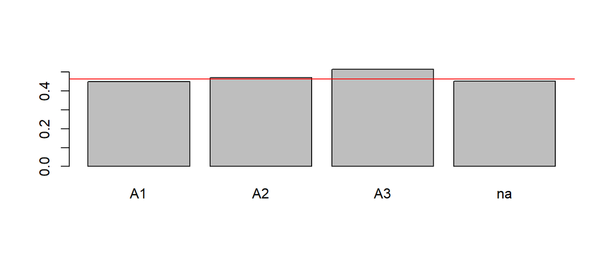

```r
tapply(A$buy, A$ageGroup, mean) %>% barplot
abline(h = mean(A$buy), col='red')
```

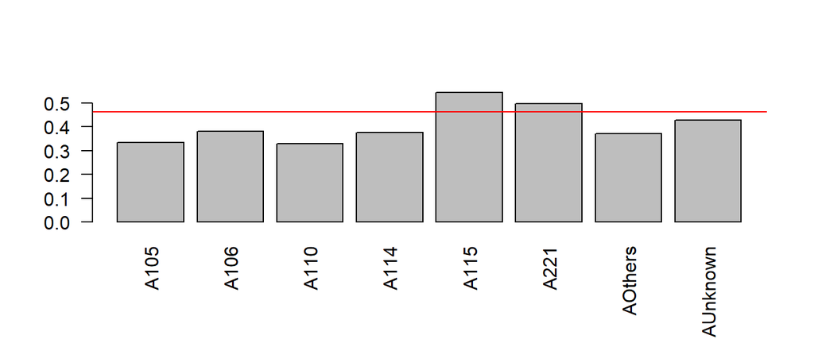

```r
tapply(A$buy, A$area, mean) %>% barplot(las=2)
abline(h = mean(A$buy), col='red')
```

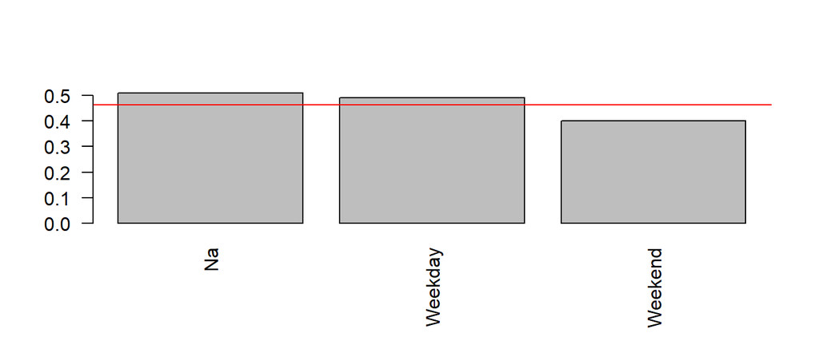

```r
tapply(A$buy, A$wdPref, mean) %>% barplot(las=2)
abline(h = mean(A$buy), col='red')
```

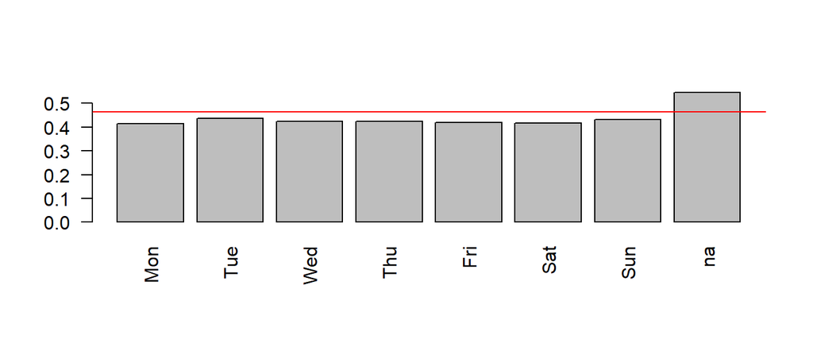

```r
tapply(A$buy, A$weekday, mean) %>% barplot(las=2)
abline(h = mean(A$buy), col='red')
```

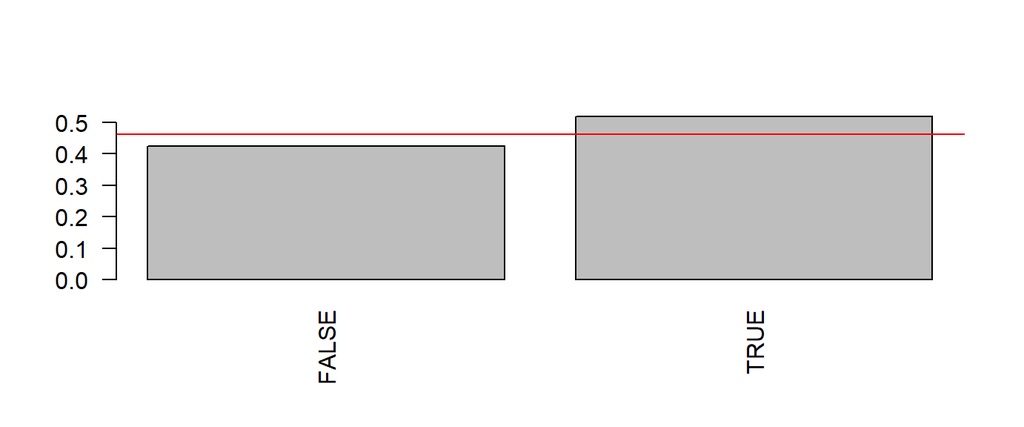

```r
tapply(A$buy, A$in114_115, mean) %>% barplot(las=2)
abline(h = mean(A$buy), col='red')
```

##### Contest Dataset

```r
X = subset(X, cid %in% A$cid & date < as.Date("2001-02-01"))
Z = subset(Z, cid %in% A$cid & date < as.Date("2001-02-01"))
set.seed(2018); spl = sample.split(A$buy, SplitRatio=0.7)
c(nrow(A), sum(spl), sum(!spl))
```

```
## [1] 28584 20008  8576
```

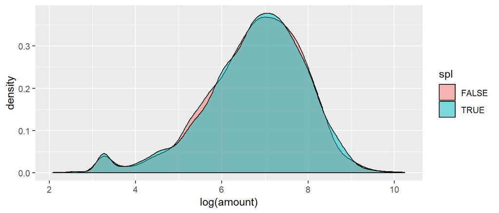

```r
cbind(A, spl) %>% filter(buy) %>%
  ggplot(aes(x=log(amount))) + geom_density(aes(fill=spl), alpha=0.5)
```

```r
A2 = subset(A, buy) %>% mutate_at(c("m","rev","amount"), log10)
n = nrow(A2)
set.seed(2018); spl2 = 1:n %in% sample(1:n, round(0.7*n))
c(nrow(A2), sum(spl2), sum(!spl2))
```

```
## [1] 13242  9269  3973
```

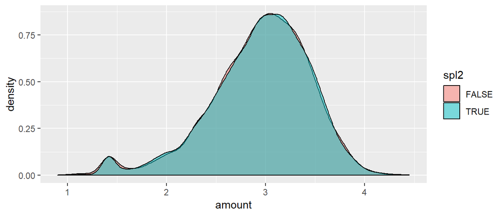

```r
cbind(A2, spl2) %>%
  ggplot(aes(x=amount)) + geom_density(aes(fill=spl2), alpha=0.5)
```

```r
save(Z, X, A, spl, spl2, file="data/tf2.rdata")
```